# Risk Factor Analysis

## Outcome Variable

**Outcome Variable:** haz

## Predictor Variables

**Intervention Variable:** earlybf

**Adjustment Set:**

- arm
- sex
- W_mage
- meducyrs
- feducyrs
- hhwealth_quart
- hfoodsec
- W_mhtcm
- W_mwtkg
- W_mbmi
- vagbrth
- W_gagebrth
- W_birthwt
- W_birthlen
- W_nrooms
- W_nchldlt5
- brthmon
- W_parity
- impfloor
- impsan
- safeh20
- delta_W_mage
- delta_meducyrs
- delta_feducyrs
- delta_hhwealth_quart
- delta_hfoodsec
- delta_W_mhtcm
- delta_W_mwtkg
- delta_W_mbmi
- delta_vagbrth
- delta_W_gagebrth
- delta_W_birthwt
- delta_W_birthlen
- delta_W_nrooms
- delta_W_nchldlt5
- delta_brthmon
- delta_W_parity
- delta_impfloor
- delta_impsan
- delta_safeh20

## Stratifying Variables

The analysis was stratified on these variable(s):

- agecat
- studyid
- country

## Data Summary

| agecat | studyid | country | earlybf | n_cell | n |
| --- | --- | --- | --- | --- | --- |
| Birth | ki0047075b-MAL-ED | BANGLADESH | 1 | 147 | 230 |
| Birth | ki0047075b-MAL-ED | BANGLADESH | 0 | 83 | 230 |
| Birth | ki0047075b-MAL-ED | BRAZIL | 1 | 28 | 65 |
| Birth | ki0047075b-MAL-ED | BRAZIL | 0 | 37 | 65 |
| Birth | ki0047075b-MAL-ED | INDIA | 1 | 32 | 46 |
| Birth | ki0047075b-MAL-ED | INDIA | 0 | 14 | 46 |
| Birth | ki0047075b-MAL-ED | NEPAL | 1 | 14 | 27 |
| Birth | ki0047075b-MAL-ED | NEPAL | 0 | 13 | 27 |
| Birth | ki0047075b-MAL-ED | PERU | 1 | 175 | 233 |
| Birth | ki0047075b-MAL-ED | PERU | 0 | 58 | 233 |
| Birth | ki0047075b-MAL-ED | SOUTH AFRICA | 1 | 69 | 111 |
| Birth | ki0047075b-MAL-ED | SOUTH AFRICA | 0 | 42 | 111 |
| Birth | ki0047075b-MAL-ED | TANZANIA, UNITED REPUBLIC OF | 1 | 111 | 125 |
| Birth | ki0047075b-MAL-ED | TANZANIA, UNITED REPUBLIC OF | 0 | 14 | 125 |
| Birth | ki1000109-EE | PAKISTAN | 1 | 44 | 229 |
| Birth | ki1000109-EE | PAKISTAN | 0 | 185 | 229 |
| Birth | ki1000304b-SAS-CompFeed | INDIA | 1 | 86 | 1207 |
| Birth | ki1000304b-SAS-CompFeed | INDIA | 0 | 1121 | 1207 |
| Birth | ki1017093c-NIH-Crypto | BANGLADESH | 1 | 634 | 732 |
| Birth | ki1017093c-NIH-Crypto | BANGLADESH | 0 | 98 | 732 |
| Birth | ki1113344-GMS-Nepal | NEPAL | 1 | 180 | 632 |
| Birth | ki1113344-GMS-Nepal | NEPAL | 0 | 452 | 632 |
| Birth | ki1126311-ZVITAMBO | ZIMBABWE | 1 | 6556 | 12354 |
| Birth | ki1126311-ZVITAMBO | ZIMBABWE | 0 | 5798 | 12354 |
| Birth | kiGH5241-JiVitA-3 | BANGLADESH | 1 | 261 | 26569 |
| Birth | kiGH5241-JiVitA-3 | BANGLADESH | 0 | 26308 | 26569 |
| Birth | kiGH5241-JiVitA-4 | BANGLADESH | 1 | 1912 | 2823 |
| Birth | kiGH5241-JiVitA-4 | BANGLADESH | 0 | 911 | 2823 |
| 6 months | ki0047075b-MAL-ED | BANGLADESH | 1 | 147 | 240 |
| 6 months | ki0047075b-MAL-ED | BANGLADESH | 0 | 93 | 240 |

[output cut: 52 more lines]

The following strata were considered:

- agecat: 24 months, studyid: ki0047075b-MAL-ED, country: BANGLADESH
- agecat: 24 months, studyid: ki0047075b-MAL-ED, country: BRAZIL
- agecat: 24 months, studyid: ki0047075b-MAL-ED, country: INDIA
- agecat: 24 months, studyid: ki0047075b-MAL-ED, country: NEPAL
- agecat: 24 months, studyid: ki0047075b-MAL-ED, country: PERU
- agecat: 24 months, studyid: ki0047075b-MAL-ED, country: SOUTH AFRICA
- agecat: 24 months, studyid: ki0047075b-MAL-ED, country: TANZANIA, UNITED REPUBLIC OF
- agecat: 24 months, studyid: ki1000109-EE, country: PAKISTAN
- agecat: 24 months, studyid: ki1017093c-NIH-Crypto, country: BANGLADESH
- agecat: 24 months, studyid: ki1113344-GMS-Nepal, country: NEPAL
- agecat: 24 months, studyid: ki1126311-ZVITAMBO, country: ZIMBABWE
- agecat: 24 months, studyid: kiGH5241-JiVitA-3, country: BANGLADESH
- agecat: 24 months, studyid: kiGH5241-JiVitA-4, country: BANGLADESH
- agecat: 6 months, studyid: ki0047075b-MAL-ED, country: BANGLADESH
- agecat: 6 months, studyid: ki0047075b-MAL-ED, country: BRAZIL
- agecat: 6 months, studyid: ki0047075b-MAL-ED, country: INDIA
- agecat: 6 months, studyid: ki0047075b-MAL-ED, country: NEPAL
- agecat: 6 months, studyid: ki0047075b-MAL-ED, country: PERU
- agecat: 6 months, studyid: ki0047075b-MAL-ED, country: SOUTH AFRICA
- agecat: 6 months, studyid: ki0047075b-MAL-ED, country: TANZANIA, UNITED REPUBLIC OF
- agecat: 6 months, studyid: ki1000109-EE, country: PAKISTAN
- agecat: 6 months, studyid: ki1000304b-SAS-CompFeed, country: INDIA
- agecat: 6 months, studyid: ki1017093c-NIH-Crypto, country: BANGLADESH
- agecat: 6 months, studyid: ki1113344-GMS-Nepal, country: NEPAL
- agecat: 6 months, studyid: ki1126311-ZVITAMBO, country: ZIMBABWE
- agecat: 6 months, studyid: kiGH5241-JiVitA-3, country: BANGLADESH
- agecat: 6 months, studyid: kiGH5241-JiVitA-4, country: BANGLADESH
- agecat: Birth, studyid: ki0047075b-MAL-ED, country: BANGLADESH
- agecat: Birth, studyid: ki0047075b-MAL-ED, country: BRAZIL
- agecat: Birth, studyid: ki0047075b-MAL-ED, country: INDIA
- agecat: Birth, studyid: ki0047075b-MAL-ED, country: NEPAL
- agecat: Birth, studyid: ki0047075b-MAL-ED, country: PERU
- agecat: Birth, studyid: ki0047075b-MAL-ED, country: SOUTH AFRICA
- agecat: Birth, studyid: ki0047075b-MAL-ED, country: TANZANIA, UNITED REPUBLIC OF
- agecat: Birth, studyid: ki1000109-EE, country: PAKISTAN
- agecat: Birth, studyid: ki1000304b-SAS-CompFeed, country: INDIA
- agecat: Birth, studyid: ki1017093c-NIH-Crypto, country: BANGLADESH
- agecat: Birth, studyid: ki1113344-GMS-Nepal, country: NEPAL
- agecat: Birth, studyid: ki1126311-ZVITAMBO, country: ZIMBABWE
- agecat: Birth, studyid: kiGH5241-JiVitA-3, country: BANGLADESH
- agecat: Birth, studyid: kiGH5241-JiVitA-4, country: BANGLADESH

### Dropped Strata

Some strata were dropped due to rare outcomes:

- agecat: 24 months, studyid: kiGH5241-JiVitA-3, country: BANGLADESH

## Methods Detail

We’re interested in the causal parameters $E[Y_a]$ for all values of $a \in \mathcal{A}$. These parameters represent the mean outcome if, possibly contrary to fact, we intervened to set all units to have $A=a$. Under the randomization and positivity assumptions, these are identified by the statistical parameters $\psi_a=E_W[E_{Y|A,W}(Y|A=a,W)]$. In addition, we’re interested in the mean of $Y$, $E[Y]$ under no intervention (the observed mean). We will estimate these parameters by using SuperLearner to fit the relevant likelihood factors – $E_{Y|A,W}(Y|A=a,W)$ and $p(A=a|W)$, and then updating our likelihood fit using a joint TMLE.

For unadjusted analyses ($W=\{\}$), initial likelihoods were estimated using Lrnr_glm to estimate the simple $E(Y|A)$ and Lrnr_mean to estimate $p(A)$. For adjusted analyses, a small library containing Lrnr_glmnet, Lrnr_xgboost, and Lrnr_mean was used.

Having estimated these parameters, we will then use the delta method to estimate relative risks and attributable risks relative to a prespecified baseline level of $A$.

# Results Detail

## Results Plots

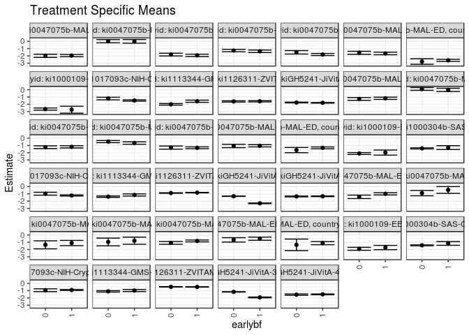

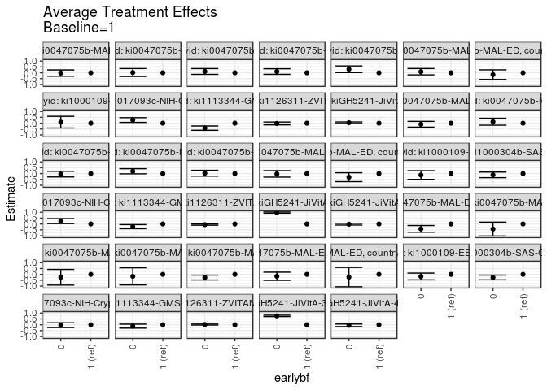

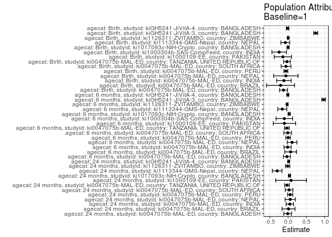

## Results Table

### Parameter: TSM

| agecat | studyid | country | intervention_level | baseline_level | estimate | ci_lower | ci_upper |
| --- | --- | --- | --- | --- | --- | --- | --- |
| Birth | ki0047075b-MAL-ED | BANGLADESH | 1 | NA | -0.9953284 | -1.1536330 | -0.8370237 |
| Birth | ki0047075b-MAL-ED | BANGLADESH | 0 | NA | -1.4141189 | -1.6506669 | -1.1775710 |
| Birth | ki0047075b-MAL-ED | BRAZIL | 1 | NA | -0.4695664 | -0.9322901 | -0.0068427 |
| Birth | ki0047075b-MAL-ED | BRAZIL | 0 | NA | -0.9029995 | -1.2671337 | -0.5388653 |
| Birth | ki0047075b-MAL-ED | INDIA | 1 | NA | -1.1073132 | -1.4703881 | -0.7442383 |
| Birth | ki0047075b-MAL-ED | INDIA | 0 | NA | -1.3537997 | -1.9053200 | -0.8022794 |
| Birth | ki0047075b-MAL-ED | NEPAL | 1 | NA | -0.7919461 | -1.2822822 | -0.3016100 |
| Birth | ki0047075b-MAL-ED | NEPAL | 0 | NA | -0.9621533 | -1.4955139 | -0.4287926 |
| Birth | ki0047075b-MAL-ED | PERU | 1 | NA | -0.8209160 | -0.9489958 | -0.6928362 |
| Birth | ki0047075b-MAL-ED | PERU | 0 | NA | -1.0919517 | -1.2847617 | -0.8991417 |
| Birth | ki0047075b-MAL-ED | SOUTH AFRICA | 1 | NA | -0.5133101 | -0.7279038 | -0.2987163 |
| Birth | ki0047075b-MAL-ED | SOUTH AFRICA | 0 | NA | -0.6743930 | -0.9779302 | -0.3708558 |
| Birth | ki0047075b-MAL-ED | TANZANIA, UNITED REPUBLIC OF | 1 | NA | -1.1240079 | -1.3402662 | -0.9077496 |
| Birth | ki0047075b-MAL-ED | TANZANIA, UNITED REPUBLIC OF | 0 | NA | -1.3603328 | -2.1563808 | -0.5642849 |
| Birth | ki1000109-EE | PAKISTAN | 1 | NA | -1.7273893 | -2.0248817 | -1.4298968 |
| Birth | ki1000109-EE | PAKISTAN | 0 | NA | -1.9064570 | -2.1098661 | -1.7030478 |
| Birth | ki1000304b-SAS-CompFeed | INDIA | 1 | NA | -1.1620947 | -1.4157610 | -0.9084284 |
| Birth | ki1000304b-SAS-CompFeed | INDIA | 0 | NA | -1.4266595 | -1.4883923 | -1.3649267 |
| Birth | ki1017093c-NIH-Crypto | BANGLADESH | 1 | NA | -0.9088964 | -0.9837741 | -0.8340187 |
| Birth | ki1017093c-NIH-Crypto | BANGLADESH | 0 | NA | -0.9432557 | -1.1370117 | -0.7494997 |
| Birth | ki1113344-GMS-Nepal | NEPAL | 1 | NA | -0.9814306 | -1.1258430 | -0.8370182 |
| Birth | ki1113344-GMS-Nepal | NEPAL | 0 | NA | -1.0985764 | -1.1960101 | -1.0011426 |
| Birth | ki1126311-ZVITAMBO | ZIMBABWE | 1 | NA | -0.4913692 | -0.5210685 | -0.4616699 |
| Birth | ki1126311-ZVITAMBO | ZIMBABWE | 0 | NA | -0.4732705 | -0.5045612 | -0.4419798 |
| Birth | kiGH5241-JiVitA-3 | BANGLADESH | 1 | NA | -1.9277444 | -1.9810171 | -1.8744717 |
| Birth | kiGH5241-JiVitA-3 | BANGLADESH | 0 | NA | -1.1681262 | -1.1969518 | -1.1393005 |
| Birth | kiGH5241-JiVitA-4 | BANGLADESH | 1 | NA | -1.5091846 | -1.5666381 | -1.4517311 |
| Birth | kiGH5241-JiVitA-4 | BANGLADESH | 0 | NA | -1.5537047 | -1.6463448 | -1.4610647 |
| 6 months | ki0047075b-MAL-ED | BANGLADESH | 1 | NA | -1.1732451 | -1.3252322 | -1.0212580 |
| 6 months | ki0047075b-MAL-ED | BANGLADESH | 0 | NA | -1.2651898 | -1.4562324 | -1.0741472 |
| 6 months | ki0047075b-MAL-ED | BRAZIL | 1 | NA | -0.0173670 | -0.2388669 | 0.2041329 |
| 6 months | ki0047075b-MAL-ED | BRAZIL | 0 | NA | 0.1054548 | -0.0856776 | 0.2965873 |
| 6 months | ki0047075b-MAL-ED | INDIA | 1 | NA | -1.1966608 | -1.3485648 | -1.0447568 |
| 6 months | ki0047075b-MAL-ED | INDIA | 0 | NA | -1.2446421 | -1.4320092 | -1.0572749 |
| 6 months | ki0047075b-MAL-ED | NEPAL | 1 | NA | -0.6686453 | -0.8321277 | -0.5051629 |
| 6 months | ki0047075b-MAL-ED | NEPAL | 0 | NA | -0.4704422 | -0.6205565 | -0.3203279 |
| 6 months | ki0047075b-MAL-ED | PERU | 1 | NA | -1.3280999 | -1.4555934 | -1.2006064 |
| 6 months | ki0047075b-MAL-ED | PERU | 0 | NA | -1.2986304 | -1.5117930 | -1.0854678 |
| 6 months | ki0047075b-MAL-ED | SOUTH AFRICA | 1 | NA | -1.0487328 | -1.2034002 | -0.8940654 |
| 6 months | ki0047075b-MAL-ED | SOUTH AFRICA | 0 | NA | -1.0736523 | -1.3050440 | -0.8422607 |
| 6 months | ki0047075b-MAL-ED | TANZANIA, UNITED REPUBLIC OF | 1 | NA | -1.3342636 | -1.4617956 | -1.2067316 |
| 6 months | ki0047075b-MAL-ED | TANZANIA, UNITED REPUBLIC OF | 0 | NA | -1.6411439 | -2.0005298 | -1.2817579 |
| 6 months | ki1000109-EE | PAKISTAN | 1 | NA | -1.9832287 | -2.3308064 | -1.6356511 |
| 6 months | ki1000109-EE | PAKISTAN | 0 | NA | -2.1064923 | -2.2355306 | -1.9774541 |
| 6 months | ki1000304b-SAS-CompFeed | INDIA | 1 | NA | -1.2991388 | -1.5622232 | -1.0360545 |
| 6 months | ki1000304b-SAS-CompFeed | INDIA | 0 | NA | -1.4090921 | -1.4843039 | -1.3338803 |
| 6 months | ki1017093c-NIH-Crypto | BANGLADESH | 1 | NA | -1.2281928 | -1.3046590 | -1.1517267 |
| 6 months | ki1017093c-NIH-Crypto | BANGLADESH | 0 | NA | -0.9829594 | -1.1815715 | -0.7843472 |
| 6 months | ki1113344-GMS-Nepal | NEPAL | 1 | NA | -1.1573673 | -1.3045129 | -1.0102217 |
| 6 months | ki1113344-GMS-Nepal | NEPAL | 0 | NA | -1.3851454 | -1.4819016 | -1.2883891 |
| 6 months | ki1126311-ZVITAMBO | ZIMBABWE | 1 | NA | -0.8353025 | -0.8707855 | -0.7998196 |
| 6 months | ki1126311-ZVITAMBO | ZIMBABWE | 0 | NA | -0.8914753 | -0.9296078 | -0.8533428 |
| 6 months | kiGH5241-JiVitA-3 | BANGLADESH | 1 | NA | -2.3068964 | -2.3529379 | -2.2608549 |
| 6 months | kiGH5241-JiVitA-3 | BANGLADESH | 0 | NA | -1.3335942 | -1.3571417 | -1.3100467 |
| 6 months | kiGH5241-JiVitA-4 | BANGLADESH | 1 | NA | -1.3365263 | -1.3823459 | -1.2907067 |
| 6 months | kiGH5241-JiVitA-4 | BANGLADESH | 0 | NA | -1.3578024 | -1.4167849 | -1.2988199 |
| 24 months | ki0047075b-MAL-ED | BANGLADESH | 1 | NA | -1.9619562 | -2.1184242 | -1.8054883 |
| 24 months | ki0047075b-MAL-ED | BANGLADESH | 0 | NA | -1.9881516 | -2.2059109 | -1.7703924 |
| 24 months | ki0047075b-MAL-ED | BRAZIL | 1 | NA | -0.0035327 | -0.2580986 | 0.2510332 |
| 24 months | ki0047075b-MAL-ED | BRAZIL | 0 | NA | 0.0179968 | -0.2071760 | 0.2431695 |
| 24 months | ki0047075b-MAL-ED | INDIA | 1 | NA | -1.9327056 | -2.0969612 | -1.7684500 |
| 24 months | ki0047075b-MAL-ED | INDIA | 0 | NA | -1.8216328 | -2.0095153 | -1.6337502 |
| 24 months | ki0047075b-MAL-ED | NEPAL | 1 | NA | -1.3687440 | -1.5440387 | -1.1934494 |
| 24 months | ki0047075b-MAL-ED | NEPAL | 0 | NA | -1.2634575 | -1.4261306 | -1.1007844 |
| 24 months | ki0047075b-MAL-ED | PERU | 1 | NA | -1.8112003 | -1.9516574 | -1.6707431 |
| 24 months | ki0047075b-MAL-ED | PERU | 0 | NA | -1.5099629 | -1.7483656 | -1.2715602 |
| 24 months | ki0047075b-MAL-ED | SOUTH AFRICA | 1 | NA | -1.6670769 | -1.8434399 | -1.4907140 |
| 24 months | ki0047075b-MAL-ED | SOUTH AFRICA | 0 | NA | -1.5751248 | -1.7839103 | -1.3663393 |
| 24 months | ki0047075b-MAL-ED | TANZANIA, UNITED REPUBLIC OF | 1 | NA | -2.6140637 | -2.7593601 | -2.4687673 |
| 24 months | ki0047075b-MAL-ED | TANZANIA, UNITED REPUBLIC OF | 0 | NA | -2.7746949 | -3.1583618 | -2.3910281 |
| 24 months | ki1000109-EE | PAKISTAN | 1 | NA | -2.7481224 | -3.2257844 | -2.2704604 |
| 24 months | ki1000109-EE | PAKISTAN | 0 | NA | -2.6602790 | -2.8087520 | -2.5118060 |
| 24 months | ki1017093c-NIH-Crypto | BANGLADESH | 1 | NA | -1.4791048 | -1.5714118 | -1.3867979 |
| 24 months | ki1017093c-NIH-Crypto | BANGLADESH | 0 | NA | -1.2110521 | -1.3885836 | -1.0335205 |
| 24 months | ki1113344-GMS-Nepal | NEPAL | 1 | NA | -1.5797837 | -1.7298757 | -1.4296918 |
| 24 months | ki1113344-GMS-Nepal | NEPAL | 0 | NA | -2.0031368 | -2.1130432 | -1.8932303 |
| 24 months | ki1126311-ZVITAMBO | ZIMBABWE | 1 | NA | -1.5875827 | -1.6739728 | -1.5011926 |
| 24 months | ki1126311-ZVITAMBO | ZIMBABWE | 0 | NA | -1.6089266 | -1.6938813 | -1.5239718 |
| 24 months | kiGH5241-JiVitA-4 | BANGLADESH | 1 | NA | -1.7958209 | -1.8400255 | -1.7516162 |
| 24 months | kiGH5241-JiVitA-4 | BANGLADESH | 0 | NA | -1.7543524 | -1.8072432 | -1.7014616 |

### Parameter: E(Y)

| agecat | studyid | country | intervention_level | baseline_level | estimate | ci_lower | ci_upper |
| --- | --- | --- | --- | --- | --- | --- | --- |
| Birth | ki0047075b-MAL-ED | BANGLADESH | NA | NA | -1.1218261 | -1.2566576 | -0.9869945 |
| Birth | ki0047075b-MAL-ED | BRAZIL | NA | NA | -0.6760000 | -0.9521457 | -0.3998543 |
| Birth | ki0047075b-MAL-ED | INDIA | NA | NA | -1.2221739 | -1.5203945 | -0.9239534 |
| Birth | ki0047075b-MAL-ED | NEPAL | NA | NA | -0.8533333 | -1.2104864 | -0.4961803 |
| Birth | ki0047075b-MAL-ED | PERU | NA | NA | -0.8827897 | -1.0001058 | -0.7654736 |
| Birth | ki0047075b-MAL-ED | SOUTH AFRICA | NA | NA | -0.5709009 | -0.7569265 | -0.3848753 |
| Birth | ki0047075b-MAL-ED | TANZANIA, UNITED REPUBLIC OF | NA | NA | -1.1556000 | -1.3655361 | -0.9456639 |
| Birth | ki1000109-EE | PAKISTAN | NA | NA | -1.8713537 | -2.0647180 | -1.6779894 |
| Birth | ki1000304b-SAS-CompFeed | INDIA | NA | NA | -1.4072245 | -1.4817853 | -1.3326638 |
| Birth | ki1017093c-NIH-Crypto | BANGLADESH | NA | NA | -0.9094945 | -0.9809370 | -0.8380521 |
| Birth | ki1113344-GMS-Nepal | NEPAL | NA | NA | -1.0578481 | -1.1411010 | -0.9745953 |
| Birth | ki1126311-ZVITAMBO | ZIMBABWE | NA | NA | -0.4895257 | -0.5113672 | -0.4676841 |
| Birth | kiGH5241-JiVitA-3 | BANGLADESH | NA | NA | -1.1723268 | -1.2004766 | -1.1441770 |
| Birth | kiGH5241-JiVitA-4 | BANGLADESH | NA | NA | -1.5232908 | -1.5723277 | -1.4742539 |
| 6 months | ki0047075b-MAL-ED | BANGLADESH | NA | NA | -1.2061389 | -1.3240265 | -1.0882513 |
| 6 months | ki0047075b-MAL-ED | BRAZIL | NA | NA | 0.0510207 | -0.0930194 | 0.1950608 |
| 6 months | ki0047075b-MAL-ED | INDIA | NA | NA | -1.2113701 | -1.3298485 | -1.0928916 |
| 6 months | ki0047075b-MAL-ED | NEPAL | NA | NA | -0.5610593 | -0.6737915 | -0.4483272 |
| 6 months | ki0047075b-MAL-ED | PERU | NA | NA | -1.3280952 | -1.4363364 | -1.2198541 |
| 6 months | ki0047075b-MAL-ED | SOUTH AFRICA | NA | NA | -1.0604867 | -1.1892706 | -0.9317027 |
| 6 months | ki0047075b-MAL-ED | TANZANIA, UNITED REPUBLIC OF | NA | NA | -1.3687449 | -1.4907629 | -1.2467270 |
| 6 months | ki1000109-EE | PAKISTAN | NA | NA | -2.0838858 | -2.2054394 | -1.9623322 |
| 6 months | ki1000304b-SAS-CompFeed | INDIA | NA | NA | -1.4018563 | -1.4810585 | -1.3226541 |
| 6 months | ki1017093c-NIH-Crypto | BANGLADESH | NA | NA | -1.1986783 | -1.2700937 | -1.1272630 |
| 6 months | ki1113344-GMS-Nepal | NEPAL | NA | NA | -1.3175310 | -1.3993963 | -1.2356656 |
| 6 months | ki1126311-ZVITAMBO | ZIMBABWE | NA | NA | -0.8625370 | -0.8897591 | -0.8353150 |
| 6 months | kiGH5241-JiVitA-3 | BANGLADESH | NA | NA | -1.3355900 | -1.3586765 | -1.3125035 |
| 6 months | kiGH5241-JiVitA-4 | BANGLADESH | NA | NA | -1.3447940 | -1.3820261 | -1.3075620 |
| 24 months | ki0047075b-MAL-ED | BANGLADESH | NA | NA | -1.9740995 | -2.1009650 | -1.8472341 |
| 24 months | ki0047075b-MAL-ED | BRAZIL | NA | NA | 0.0071006 | -0.1615817 | 0.1757828 |
| 24 months | ki0047075b-MAL-ED | INDIA | NA | NA | -1.8848458 | -2.0096941 | -1.7599975 |
| 24 months | ki0047075b-MAL-ED | NEPAL | NA | NA | -1.3118640 | -1.4315132 | -1.1922149 |
| 24 months | ki0047075b-MAL-ED | PERU | NA | NA | -1.7544776 | -1.8753255 | -1.6336298 |
| 24 months | ki0047075b-MAL-ED | SOUTH AFRICA | NA | NA | -1.6406809 | -1.7768402 | -1.5045215 |
| 24 months | ki0047075b-MAL-ED | TANZANIA, UNITED REPUBLIC OF | NA | NA | -2.6451636 | -2.7802323 | -2.5100948 |
| 24 months | ki1000109-EE | PAKISTAN | NA | NA | -2.6678252 | -2.8138884 | -2.5217620 |
| 24 months | ki1017093c-NIH-Crypto | BANGLADESH | NA | NA | -1.4412646 | -1.5249156 | -1.3576135 |
| 24 months | ki1113344-GMS-Nepal | NEPAL | NA | NA | -1.8793783 | -1.9705101 | -1.7882464 |
| 24 months | ki1126311-ZVITAMBO | ZIMBABWE | NA | NA | -1.6006366 | -1.6621572 | -1.5391159 |
| 24 months | kiGH5241-JiVitA-4 | BANGLADESH | NA | NA | -1.7807218 | -1.8162478 | -1.7451958 |

### Parameter: ATE

| agecat | studyid | country | intervention_level | baseline_level | estimate | ci_lower | ci_upper |
| --- | --- | --- | --- | --- | --- | --- | --- |
| Birth | ki0047075b-MAL-ED | BANGLADESH | 1 | 1 | 0.0000000 | 0.0000000 | 0.0000000 |
| Birth | ki0047075b-MAL-ED | BANGLADESH | 0 | 1 | -0.4187906 | -0.7054726 | -0.1321085 |
| Birth | ki0047075b-MAL-ED | BRAZIL | 1 | 1 | 0.0000000 | 0.0000000 | 0.0000000 |
| Birth | ki0047075b-MAL-ED | BRAZIL | 0 | 1 | -0.4334331 | -1.0225530 | 0.1556868 |
| Birth | ki0047075b-MAL-ED | INDIA | 1 | 1 | 0.0000000 | 0.0000000 | 0.0000000 |
| Birth | ki0047075b-MAL-ED | INDIA | 0 | 1 | -0.2464865 | -0.9155819 | 0.4226089 |
| Birth | ki0047075b-MAL-ED | NEPAL | 1 | 1 | 0.0000000 | 0.0000000 | 0.0000000 |
| Birth | ki0047075b-MAL-ED | NEPAL | 0 | 1 | -0.1702072 | -0.9016154 | 0.5612011 |
| Birth | ki0047075b-MAL-ED | PERU | 1 | 1 | 0.0000000 | 0.0000000 | 0.0000000 |
| Birth | ki0047075b-MAL-ED | PERU | 0 | 1 | -0.2710357 | -0.4791381 | -0.0629333 |
| Birth | ki0047075b-MAL-ED | SOUTH AFRICA | 1 | 1 | 0.0000000 | 0.0000000 | 0.0000000 |
| Birth | ki0047075b-MAL-ED | SOUTH AFRICA | 0 | 1 | -0.1610829 | -0.5108091 | 0.1886433 |
| Birth | ki0047075b-MAL-ED | TANZANIA, UNITED REPUBLIC OF | 1 | 1 | 0.0000000 | 0.0000000 | 0.0000000 |
| Birth | ki0047075b-MAL-ED | TANZANIA, UNITED REPUBLIC OF | 0 | 1 | -0.2363249 | -1.0619116 | 0.5892618 |
| Birth | ki1000109-EE | PAKISTAN | 1 | 1 | 0.0000000 | 0.0000000 | 0.0000000 |
| Birth | ki1000109-EE | PAKISTAN | 0 | 1 | -0.1790677 | -0.4683358 | 0.1102003 |
| Birth | ki1000304b-SAS-CompFeed | INDIA | 1 | 1 | 0.0000000 | 0.0000000 | 0.0000000 |
| Birth | ki1000304b-SAS-CompFeed | INDIA | 0 | 1 | -0.2645648 | -0.4678017 | -0.0613278 |
| Birth | ki1017093c-NIH-Crypto | BANGLADESH | 1 | 1 | 0.0000000 | 0.0000000 | 0.0000000 |
| Birth | ki1017093c-NIH-Crypto | BANGLADESH | 0 | 1 | -0.0343593 | -0.2374717 | 0.1687531 |
| Birth | ki1113344-GMS-Nepal | NEPAL | 1 | 1 | 0.0000000 | 0.0000000 | 0.0000000 |
| Birth | ki1113344-GMS-Nepal | NEPAL | 0 | 1 | -0.1171458 | -0.2862215 | 0.0519300 |
| Birth | ki1126311-ZVITAMBO | ZIMBABWE | 1 | 1 | 0.0000000 | 0.0000000 | 0.0000000 |
| Birth | ki1126311-ZVITAMBO | ZIMBABWE | 0 | 1 | 0.0180987 | -0.0236477 | 0.0598451 |
| Birth | kiGH5241-JiVitA-3 | BANGLADESH | 1 | 1 | 0.0000000 | 0.0000000 | 0.0000000 |
| Birth | kiGH5241-JiVitA-3 | BANGLADESH | 0 | 1 | 0.7596183 | 0.7003851 | 0.8188515 |
| Birth | kiGH5241-JiVitA-4 | BANGLADESH | 1 | 1 | 0.0000000 | 0.0000000 | 0.0000000 |
| Birth | kiGH5241-JiVitA-4 | BANGLADESH | 0 | 1 | -0.0445202 | -0.1535478 | 0.0645074 |
| 6 months | ki0047075b-MAL-ED | BANGLADESH | 1 | 1 | 0.0000000 | 0.0000000 | 0.0000000 |
| 6 months | ki0047075b-MAL-ED | BANGLADESH | 0 | 1 | -0.0919447 | -0.3371078 | 0.1532183 |
| 6 months | ki0047075b-MAL-ED | BRAZIL | 1 | 1 | 0.0000000 | 0.0000000 | 0.0000000 |
| 6 months | ki0047075b-MAL-ED | BRAZIL | 0 | 1 | 0.1228218 | -0.1709727 | 0.4166164 |
| 6 months | ki0047075b-MAL-ED | INDIA | 1 | 1 | 0.0000000 | 0.0000000 | 0.0000000 |
| 6 months | ki0047075b-MAL-ED | INDIA | 0 | 1 | -0.0479813 | -0.2901919 | 0.1942293 |
| 6 months | ki0047075b-MAL-ED | NEPAL | 1 | 1 | 0.0000000 | 0.0000000 | 0.0000000 |
| 6 months | ki0047075b-MAL-ED | NEPAL | 0 | 1 | 0.1982031 | -0.0202074 | 0.4166136 |
| 6 months | ki0047075b-MAL-ED | PERU | 1 | 1 | 0.0000000 | 0.0000000 | 0.0000000 |
| 6 months | ki0047075b-MAL-ED | PERU | 0 | 1 | 0.0294695 | -0.2198577 | 0.2787967 |
| 6 months | ki0047075b-MAL-ED | SOUTH AFRICA | 1 | 1 | 0.0000000 | 0.0000000 | 0.0000000 |
| 6 months | ki0047075b-MAL-ED | SOUTH AFRICA | 0 | 1 | -0.0249196 | -0.3038984 | 0.2540592 |
| 6 months | ki0047075b-MAL-ED | TANZANIA, UNITED REPUBLIC OF | 1 | 1 | 0.0000000 | 0.0000000 | 0.0000000 |
| 6 months | ki0047075b-MAL-ED | TANZANIA, UNITED REPUBLIC OF | 0 | 1 | -0.3068803 | -0.6869087 | 0.0731482 |
| 6 months | ki1000109-EE | PAKISTAN | 1 | 1 | 0.0000000 | 0.0000000 | 0.0000000 |
| 6 months | ki1000109-EE | PAKISTAN | 0 | 1 | -0.1232636 | -0.4935832 | 0.2470560 |
| 6 months | ki1000304b-SAS-CompFeed | INDIA | 1 | 1 | 0.0000000 | 0.0000000 | 0.0000000 |
| 6 months | ki1000304b-SAS-CompFeed | INDIA | 0 | 1 | -0.1099532 | -0.3505934 | 0.1306869 |
| 6 months | ki1017093c-NIH-Crypto | BANGLADESH | 1 | 1 | 0.0000000 | 0.0000000 | 0.0000000 |
| 6 months | ki1017093c-NIH-Crypto | BANGLADESH | 0 | 1 | 0.2452335 | 0.0324746 | 0.4579923 |
| 6 months | ki1113344-GMS-Nepal | NEPAL | 1 | 1 | 0.0000000 | 0.0000000 | 0.0000000 |
| 6 months | ki1113344-GMS-Nepal | NEPAL | 0 | 1 | -0.2277781 | -0.4026217 | -0.0529344 |
| 6 months | ki1126311-ZVITAMBO | ZIMBABWE | 1 | 1 | 0.0000000 | 0.0000000 | 0.0000000 |
| 6 months | ki1126311-ZVITAMBO | ZIMBABWE | 0 | 1 | -0.0561728 | -0.1053914 | -0.0069541 |
| 6 months | kiGH5241-JiVitA-3 | BANGLADESH | 1 | 1 | 0.0000000 | 0.0000000 | 0.0000000 |
| 6 months | kiGH5241-JiVitA-3 | BANGLADESH | 0 | 1 | 0.9733022 | 0.9222980 | 1.0243063 |
| 6 months | kiGH5241-JiVitA-4 | BANGLADESH | 1 | 1 | 0.0000000 | 0.0000000 | 0.0000000 |
| 6 months | kiGH5241-JiVitA-4 | BANGLADESH | 0 | 1 | -0.0212761 | -0.0935907 | 0.0510386 |
| 24 months | ki0047075b-MAL-ED | BANGLADESH | 1 | 1 | 0.0000000 | 0.0000000 | 0.0000000 |
| 24 months | ki0047075b-MAL-ED | BANGLADESH | 0 | 1 | -0.0261954 | -0.2948276 | 0.2424368 |
| 24 months | ki0047075b-MAL-ED | BRAZIL | 1 | 1 | 0.0000000 | 0.0000000 | 0.0000000 |
| 24 months | ki0047075b-MAL-ED | BRAZIL | 0 | 1 | 0.0215295 | -0.3173791 | 0.3604381 |
| 24 months | ki0047075b-MAL-ED | INDIA | 1 | 1 | 0.0000000 | 0.0000000 | 0.0000000 |
| 24 months | ki0047075b-MAL-ED | INDIA | 0 | 1 | 0.1110728 | -0.1354218 | 0.3575675 |
| 24 months | ki0047075b-MAL-ED | NEPAL | 1 | 1 | 0.0000000 | 0.0000000 | 0.0000000 |
| 24 months | ki0047075b-MAL-ED | NEPAL | 0 | 1 | 0.1052865 | -0.1333524 | 0.3439255 |
| 24 months | ki0047075b-MAL-ED | PERU | 1 | 1 | 0.0000000 | 0.0000000 | 0.0000000 |
| 24 months | ki0047075b-MAL-ED | PERU | 0 | 1 | 0.3012374 | 0.0197896 | 0.5826852 |
| 24 months | ki0047075b-MAL-ED | SOUTH AFRICA | 1 | 1 | 0.0000000 | 0.0000000 | 0.0000000 |
| 24 months | ki0047075b-MAL-ED | SOUTH AFRICA | 0 | 1 | 0.0919522 | -0.1783982 | 0.3623025 |
| 24 months | ki0047075b-MAL-ED | TANZANIA, UNITED REPUBLIC OF | 1 | 1 | 0.0000000 | 0.0000000 | 0.0000000 |
| 24 months | ki0047075b-MAL-ED | TANZANIA, UNITED REPUBLIC OF | 0 | 1 | -0.1606312 | -0.5714732 | 0.2502108 |
| 24 months | ki1000109-EE | PAKISTAN | 1 | 1 | 0.0000000 | 0.0000000 | 0.0000000 |
| 24 months | ki1000109-EE | PAKISTAN | 0 | 1 | 0.0878434 | -0.4110430 | 0.5867298 |
| 24 months | ki1017093c-NIH-Crypto | BANGLADESH | 1 | 1 | 0.0000000 | 0.0000000 | 0.0000000 |
| 24 months | ki1017093c-NIH-Crypto | BANGLADESH | 0 | 1 | 0.2680527 | 0.0684295 | 0.4676759 |
| 24 months | ki1113344-GMS-Nepal | NEPAL | 1 | 1 | 0.0000000 | 0.0000000 | 0.0000000 |
| 24 months | ki1113344-GMS-Nepal | NEPAL | 0 | 1 | -0.4233530 | -0.6084553 | -0.2382507 |
| 24 months | ki1126311-ZVITAMBO | ZIMBABWE | 1 | 1 | 0.0000000 | 0.0000000 | 0.0000000 |
| 24 months | ki1126311-ZVITAMBO | ZIMBABWE | 0 | 1 | -0.0213439 | -0.1409631 | 0.0982753 |
| 24 months | kiGH5241-JiVitA-4 | BANGLADESH | 1 | 1 | 0.0000000 | 0.0000000 | 0.0000000 |
| 24 months | kiGH5241-JiVitA-4 | BANGLADESH | 0 | 1 | 0.0414685 | -0.0237475 | 0.1066844 |

### Parameter: PAR

| agecat | studyid | country | intervention_level | baseline_level | estimate | ci_lower | ci_upper |
| --- | --- | --- | --- | --- | --- | --- | --- |
| Birth | ki0047075b-MAL-ED | BANGLADESH | 1 | NA | -0.1264977 | -0.2331492 | -0.0198462 |
| Birth | ki0047075b-MAL-ED | BRAZIL | 1 | NA | -0.2064336 | -0.5904881 | 0.1776210 |
| Birth | ki0047075b-MAL-ED | INDIA | 1 | NA | -0.1148607 | -0.3132285 | 0.0835070 |
| Birth | ki0047075b-MAL-ED | NEPAL | 1 | NA | -0.0613872 | -0.3958227 | 0.2730482 |
| Birth | ki0047075b-MAL-ED | PERU | 1 | NA | -0.0618737 | -0.1147212 | -0.0090263 |
| Birth | ki0047075b-MAL-ED | SOUTH AFRICA | 1 | NA | -0.0575908 | -0.1903584 | 0.0751767 |
| Birth | ki0047075b-MAL-ED | TANZANIA, UNITED REPUBLIC OF | 1 | NA | -0.0315921 | -0.1210681 | 0.0578839 |
| Birth | ki1000109-EE | PAKISTAN | 1 | NA | -0.1439644 | -0.3806835 | 0.0927546 |
| Birth | ki1000304b-SAS-CompFeed | INDIA | 1 | NA | -0.2451298 | -0.4429120 | -0.0473476 |
| Birth | ki1017093c-NIH-Crypto | BANGLADESH | 1 | NA | -0.0005982 | -0.0281032 | 0.0269069 |
| Birth | ki1113344-GMS-Nepal | NEPAL | 1 | NA | -0.0764175 | -0.1978714 | 0.0450364 |
| Birth | ki1126311-ZVITAMBO | ZIMBABWE | 1 | NA | 0.0018435 | -0.0193218 | 0.0230088 |
| Birth | kiGH5241-JiVitA-3 | BANGLADESH | 1 | NA | 0.7554177 | 0.6979660 | 0.8128694 |
| Birth | kiGH5241-JiVitA-4 | BANGLADESH | 1 | NA | -0.0141062 | -0.0492531 | 0.0210406 |
| 6 months | ki0047075b-MAL-ED | BANGLADESH | 1 | NA | -0.0328938 | -0.1286363 | 0.0628486 |
| 6 months | ki0047075b-MAL-ED | BRAZIL | 1 | NA | 0.0683877 | -0.0923637 | 0.2291391 |
| 6 months | ki0047075b-MAL-ED | INDIA | 1 | NA | -0.0147093 | -0.1132002 | 0.0837816 |
| 6 months | ki0047075b-MAL-ED | NEPAL | 1 | NA | 0.1075860 | -0.0233721 | 0.2385441 |
| 6 months | ki0047075b-MAL-ED | PERU | 1 | NA | 0.0000047 | -0.0632695 | 0.0632789 |
| 6 months | ki0047075b-MAL-ED | SOUTH AFRICA | 1 | NA | -0.0117539 | -0.1163006 | 0.0927928 |
| 6 months | ki0047075b-MAL-ED | TANZANIA, UNITED REPUBLIC OF | 1 | NA | -0.0344813 | -0.0983903 | 0.0294276 |
| 6 months | ki1000109-EE | PAKISTAN | 1 | NA | -0.1006571 | -0.4070728 | 0.2057587 |
| 6 months | ki1000304b-SAS-CompFeed | INDIA | 1 | NA | -0.1027174 | -0.3298838 | 0.1244490 |
| 6 months | ki1017093c-NIH-Crypto | BANGLADESH | 1 | NA | 0.0295145 | 0.0009491 | 0.0580799 |
| 6 months | ki1113344-GMS-Nepal | NEPAL | 1 | NA | -0.1601637 | -0.2837430 | -0.0365844 |
| 6 months | ki1126311-ZVITAMBO | ZIMBABWE | 1 | NA | -0.0272345 | -0.0503636 | -0.0041054 |
| 6 months | kiGH5241-JiVitA-3 | BANGLADESH | 1 | NA | 0.9713063 | 0.9214986 | 1.0211140 |
| 6 months | kiGH5241-JiVitA-4 | BANGLADESH | 1 | NA | -0.0082677 | -0.0343014 | 0.0177660 |
| 24 months | ki0047075b-MAL-ED | BANGLADESH | 1 | NA | -0.0121433 | -0.1173624 | 0.0930758 |
| 24 months | ki0047075b-MAL-ED | BRAZIL | 1 | NA | 0.0106333 | -0.1677302 | 0.1889968 |
| 24 months | ki0047075b-MAL-ED | INDIA | 1 | NA | 0.0478598 | -0.0533644 | 0.1490840 |
| 24 months | ki0047075b-MAL-ED | NEPAL | 1 | NA | 0.0568800 | -0.0825165 | 0.1962765 |
| 24 months | ki0047075b-MAL-ED | PERU | 1 | NA | 0.0567226 | -0.0135723 | 0.1270176 |
| 24 months | ki0047075b-MAL-ED | SOUTH AFRICA | 1 | NA | 0.0263961 | -0.0790763 | 0.1318684 |
| 24 months | ki0047075b-MAL-ED | TANZANIA, UNITED REPUBLIC OF | 1 | NA | -0.0310998 | -0.0950743 | 0.0328746 |
| 24 months | ki1000109-EE | PAKISTAN | 1 | NA | 0.0802972 | -0.3406222 | 0.5012166 |
| 24 months | ki1017093c-NIH-Crypto | BANGLADESH | 1 | NA | 0.0378402 | 0.0094110 | 0.0662694 |
| 24 months | ki1113344-GMS-Nepal | NEPAL | 1 | NA | -0.2995945 | -0.4319483 | -0.1672408 |
| 24 months | ki1126311-ZVITAMBO | ZIMBABWE | 1 | NA | -0.0130539 | -0.0722558 | 0.0461480 |
| 24 months | kiGH5241-JiVitA-4 | BANGLADESH | 1 | NA | 0.0150991 | -0.0083558 | 0.0385540 |